# Predicting Customer Conversion @ Bank Telemarketing Campaign

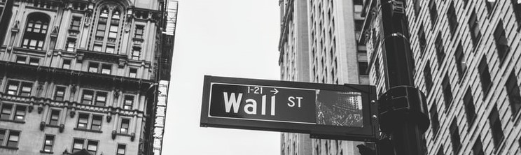

# 1. Business Problem

## 1.1. Background

Due to the digital transformation of the world and circumstances caused by Covid 19 companies speed up developing of online and telemarketing marketing channels to reach the customers.

Companies spend from **$1 to $10** per customer call. This is huge budget in big scale. However, there are ways to optimize the return on investment (ROI). Companies can develop machine learning models to predict which customer has more chance to be converted. This way companies can target right customer and optimize marketing activities to get higher ROI.

## 1.3. Dataset source

The dataset is from the UCI Machine Learning Repository.

The data is related with direct marketing campaigns (phone calls) of a Portuguese banking institution.

`bank-additional-full.csv` with all examples (41188) and 20 inputs, ordered by date (from May 2008 to November 2010), very close to the data analyzed in 1[Moro et al., 2014]1

Link to the source: https://archive.ics.uci.edu/ml/datasets/Bank+Marketing

Source Paper: [Moro et al., 2014] S. Moro, P. Cortez and P. Rita. A Data-Driven Approach to Predict the Success of Bank Telemarketing. Decision Support Systems, Elsevier, 62:22-31, June 2014

# 2. Prepare Problem

## 2.1. Load libraries

```r
library(psych)  # tests, correlation
library(knitr)  # tables
library(plyr)  # data manipulation
library(dplyr)  # data manipulation
library(caret)  # models
library(corrplot)  # correlation plots
library(DALEX)  # explain models
library(DescTools)  # plots
library(doParallel)  # parallel processing
library(dplyr)  # syntax
library(ggplot2)  # plots
library(inspectdf)  # data overview
library(readr)  # quick load
library(sjPlot)  # contingency tables
library(tictoc)  # measure time
library(funModeling)  # data preparation
library(purrr)  # functional programming
library(yarrr)  # nice plots
library(expss)  # computation
library(verification)  # model verification
library(janitor)  # cleaning data
library(class)  # classification algorithms
library(kernlab)  # Kernel-based ml methods
library(MASS)  # functions and datasets
library(rmarkdown)  # r markdown
library(formatR)  # plots formatting
```

## 2.2. Load dataset

```r
data <- read_csv("bank_marketing.csv")
```

# 3. Summarize Data

## 3.1. Feature description

Let’s check the columns names of the dataset:

```r
colnames(data)
```

[1] “age” “job” “marital” “education”  
[5] “default” “housing” “loan” “contact”  
[9] “month” “day_of_week” “duration” “campaign”  
[13] “pdays” “previous” “poutcome” “emp.var.rate”  
[17] “cons.price.idx” “cons.conf.idx” “euribor3m” “nr.employed”  
[21] “y”

Let’s change the name of output variable from `y` to `deposit` to make it more intuitive.

```r
names(data)[names(data) == "y"] <- "deposit"
```

**Bank client data:**

1. `age` (numeric)
2. `job` type of job (categorical: ‘admin.’,‘blue-collar’,‘entrepreneur’,‘housemaid’,‘management’,‘retired’,‘self-employed’,‘services’,‘student’,‘technician’,‘unemployed’,‘unknown’)
3. `marital` marital status (categorical: ‘divorced’,‘married’,‘single’,‘unknown’; note: ‘divorced’ means divorced or widowed)
4. `education` (categorical: basic.4y’,‘basic.6y’,‘basic.9y’,‘high.school’,‘illiterate’,‘professional.course’,‘university.degree’,‘unknown’)
5. `default` has credit in default? (categorical: ‘no’,‘yes’,‘unknown’)
6. `housing` has housing loan? (categorical: ‘no’,‘yes’,‘unknown’)
7. `loan` has personal loan? (categorical: ‘no’,‘yes’,‘unknown’)

**campaign related attributes:**

8. `contact` contact communication type (categorical: ‘cellular’,‘telephone’)
9. `month` last contact month of year (categorical: ‘jan’, ‘feb’, ‘mar’, …, ‘nov’, ‘dec’)
10. `day_of_week` last contact day of the week (categorical: ‘mon’,‘tue’,‘wed’,‘thu’,‘fri’)
11. `duration` last contact duration, in seconds (numeric). Important note: this attribute highly affects the output target (e.g., if duration=0 then y=‘no’). Yet, the duration is not known before a call is performed. Also, after the end of the call y is obviously known. Thus, this input should only be included for benchmark purposes and should be discarded if the intention is to have a realistic predictive model.
12. `campaign` number of contacts performed during this campaign and for this client (numeric, includes last contact)
13. `pdays` number of days that passed by after the client was last contacted from a previous campaign (numeric; 999 means client was not previously contacted)
14. `previous` number of contacts performed before this campaign and for this client (numeric)
15. `poutcome` outcome of the previous marketing campaign (categorical: ‘failure’,‘nonexistent’,‘success’)

**social and economic attributes:**

16. `emp.var.rate` employment variation rate - quarterly indicator (numeric)
17. `cons.price.idx` consumer price index - monthly indicator (numeric)
18. `cons.conf.idx` consumer confidence index - monthly indicator (numeric)
19. `euribor3m` euribor 3 month rate - daily indicator (numeric)
20. `nr.employed` number of employees - quarterly indicator (numeric)

**Output/dependent/target variable:**

21. `deposit` - has the client subscribed a term deposit? (binary: ‘yes’,‘no’)

## 3.2. Descriptive statistics

```r
paste("The dataset initialy has", dim(data)[1], "rows and",  dim(data)[2], "columns")
```

[1] “The dataset initialy has 41188 rows and 21 columns”

```r
kable(data[1:10,], capture = "Dataset first 10 records")
```

| age | job | marital | education | default | housing | loan | contact | month | day_of_week | duration | campaign | pdays | previous | poutcome | emp.var.rate | cons.price.idx | cons.conf.idx | euribor3m | nr.employed | deposit |
| --- | --- | --- | --- | --- | --- | --- | --- | --- | --- | --- | --- | --- | --- | --- | --- | --- | --- | --- | --- | --- |
| 56 | housemaid | married | basic.4y | no | no | no | telephone | may | mon | 261 | 1 | 999 | 0 | nonexistent | 1.1 | 93.994 | -36.4 | 4.857 | 5191 | no |
| 57 | services | married | high.school | unknown | no | no | telephone | may | mon | 149 | 1 | 999 | 0 | nonexistent | 1.1 | 93.994 | -36.4 | 4.857 | 5191 | no |
| 37 | services | married | high.school | no | yes | no | telephone | may | mon | 226 | 1 | 999 | 0 | nonexistent | 1.1 | 93.994 | -36.4 | 4.857 | 5191 | no |
| 40 | admin. | married | basic.6y | no | no | no | telephone | may | mon | 151 | 1 | 999 | 0 | nonexistent | 1.1 | 93.994 | -36.4 | 4.857 | 5191 | no |
| 56 | services | married | high.school | no | no | yes | telephone | may | mon | 307 | 1 | 999 | 0 | nonexistent | 1.1 | 93.994 | -36.4 | 4.857 | 5191 | no |
| 45 | services | married | basic.9y | unknown | no | no | telephone | may | mon | 198 | 1 | 999 | 0 | nonexistent | 1.1 | 93.994 | -36.4 | 4.857 | 5191 | no |
| 59 | admin. | married | professional.course | no | no | no | telephone | may | mon | 139 | 1 | 999 | 0 | nonexistent | 1.1 | 93.994 | -36.4 | 4.857 | 5191 | no |
| 41 | blue-collar | married | unknown | unknown | no | no | telephone | may | mon | 217 | 1 | 999 | 0 | nonexistent | 1.1 | 93.994 | -36.4 | 4.857 | 5191 | no |
| 24 | technician | single | professional.course | no | yes | no | telephone | may | mon | 380 | 1 | 999 | 0 | nonexistent | 1.1 | 93.994 | -36.4 | 4.857 | 5191 | no |
| 25 | services | single | high.school | no | yes | no | telephone | may | mon | 50 | 1 | 999 | 0 | nonexistent | 1.1 | 93.994 | -36.4 | 4.857 | 5191 | no |

**Explore categorical variables**

Let’s find all character variables in our dataset, convert them as factor and and save names as a vector.

```r
data <- data %>% purrr::modify_at(colnames(data[, sapply(data, class) == 'character']), as.factor)

data_categorical_vars <- colnames(data[, sapply(data, class) == 'factor'])

data_categorical_vars # categorical variables
```

[1] “job” “marital” “education” “default” “housing”  
[6] “loan” “contact” “month” “day_of_week” “poutcome”  
[11] “deposit”

*Job vs Deposit

|  | #Total | admin. | blue-collar | entrepreneur | housemaid | management | retired | self-employed | services | student | technician | unemployed | unknown |
| --- | --- | --- | --- | --- | --- | --- | --- | --- | --- | --- | --- | --- | --- |
| data$deposit |  |  |  |  |  |  |  |  |  |  |  |  |  |
| no | 88.7 | 87 | 93.1 | 91.5 | 90 | 88.8 | 74.8 | 89.5 | 91.9 | 68.6 | 89.2 | 85.8 | 88.8 |
| yes | 11.3 | 13 | 6.9 | 8.5 | 10 | 11.2 | 25.2 | 10.5 | 8.1 | 31.4 | 10.8 | 14.2 | 11.2 |
| #Total cases | 41188 | 10422 | 9254 | 1456 | 1060 | 2924 | 1720 | 1421 | 3969 | 875 | 6743 | 1014 | 330 |

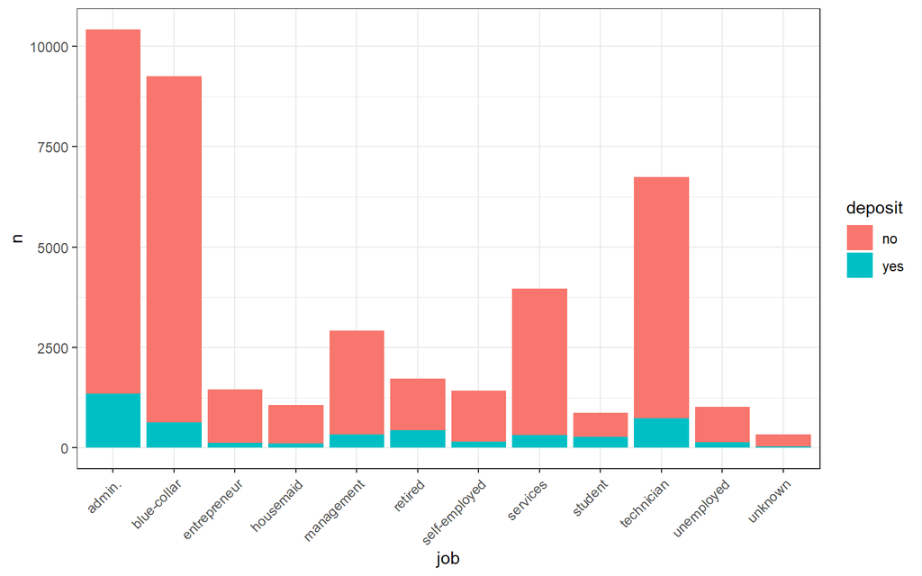

*Education vs Deposit

|  | #Total | basic.4y | basic.6y | basic.9y | high.school | illiterate | professional.course | university.degree | unknown |
| --- | --- | --- | --- | --- | --- | --- | --- | --- | --- |
| data$deposit |  |  |  |  |  |  |  |  |  |
| no | 88.7 | 89.8 | 91.8 | 92.2 | 89.2 | 77.8 | 88.7 | 86.3 | 85.5 |
| yes | 11.3 | 10.2 | 8.2 | 7.8 | 10.8 | 22.2 | 11.3 | 13.7 | 14.5 |
| #Total cases | 41188 | 4176 | 2292 | 6045 | 9515 | 18 | 5243 | 12168 | 1731 |

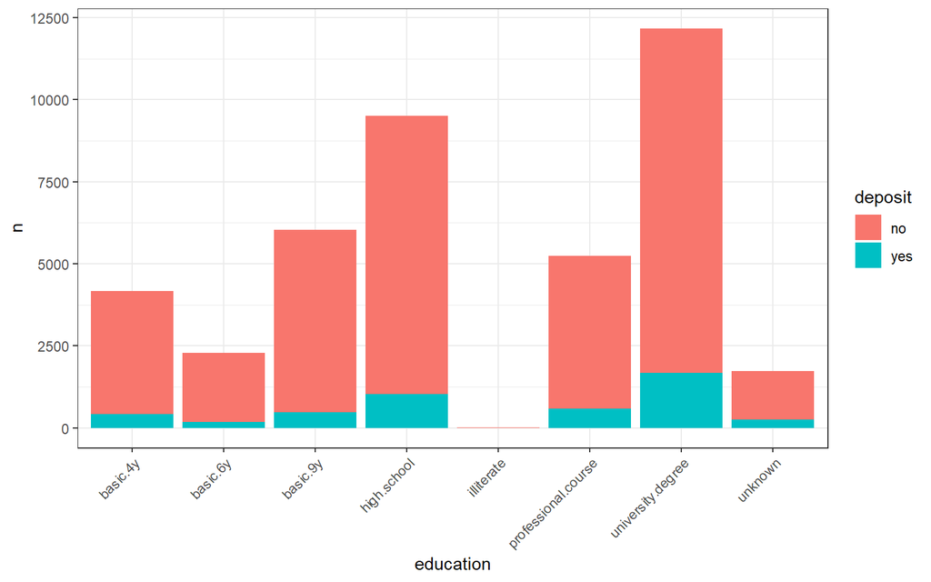

Let’s check the dependent variable - deposit

no yes 36548 4640

**Explore Numerical variables**

Lets identify numeric variables and save names as a vector.

```r
data_numeric_vars <- colnames(data[, sapply(data, class) == 'numeric'])
```

Let’s explore how many unique values does each numeric variable have and sort variables by increasing number of levels in the end.

```r
sapply(data[, data_numeric_vars],
       function(x)
         unique(x) %>%
         length()) %>%
  sort()
```

```
      previous   emp.var.rate    nr.employed cons.price.idx  cons.conf.idx
             8             10             11             26             26
         pdays       campaign            age      euribor3m       duration
            27             42             78            316           1544
```

```r
summary(data)
```

```
      age                 job            marital
 Min.   :17.00   admin.     :10422   divorced: 4612
 1st Qu.:32.00   blue-collar: 9254   married :24928
 Median :38.00   technician : 6743   single  :11568
               education        default         housing           loan
 university.degree  :12168   no     :32588   no     :18622   no     :33950
 high.school        : 9515   unknown: 8597   unknown:  990   unknown:  990
 basic.9y           : 6045   yes    :    3   yes    :21576   yes    : 6248
      contact          month       day_of_week    duration
 cellular :26144   may    :13769   fri:7827    Min.   :   0.0
 telephone:15044   jul    : 7174   mon:8514    1st Qu.: 102.0
                   aug    : 6178   thu:8623    Median : 180.0
    campaign          pdays          previous            poutcome
 Min.   : 1.000   Min.   :  0.0   Min.   :0.000   failure    : 4252
 1st Qu.: 1.000   1st Qu.:999.0   1st Qu.:0.000   nonexistent:35563
 Median : 2.000   Median :999.0   Median :0.000   success    : 1373
  emp.var.rate      cons.price.idx  cons.conf.idx     euribor3m
 Min.   :-3.40000   Min.   :92.20   Min.   :-50.8   Min.   :0.634
 1st Qu.:-1.80000   1st Qu.:93.08   1st Qu.:-42.7   1st Qu.:1.344
 Median : 1.10000   Median :93.75   Median :-41.8   Median :4.857
  nr.employed   deposit
 Min.   :4964   no :36548
 1st Qu.:5099   yes: 4640
 Median :5191
 [ reached getOption("max.print") -- omitted 4 rows ]
```

## 3.3. Data visualizations

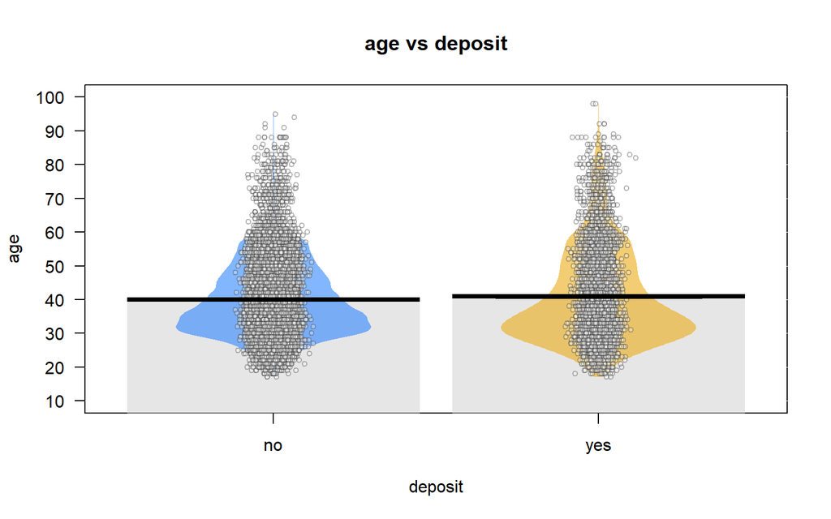

```r
par(mfrow=c(1,1))

pirateplot(formula = age ~ deposit,
           data = data,
           theme = 0,
           main = "age vs deposit",
           pal = "southpark", # southpark color palette
           bean.f.o = .6, # Bean fill
           point.o = .3, # Points
           inf.f.o = .7, # Inference fill
           inf.b.o = .8, # Inference border
           avg.line.o = 1, # Average line
           bar.f.o = .5, # Bar
           inf.f.col = "white", # Inf fill col
           inf.b.col = "black", # Inf border col
           avg.line.col = "black", # avg line col
           bar.f.col = gray(.8), # bar filling color
           point.pch = 21,
           point.bg = "white",
           point.col = "black",
           point.cex = .7)
```

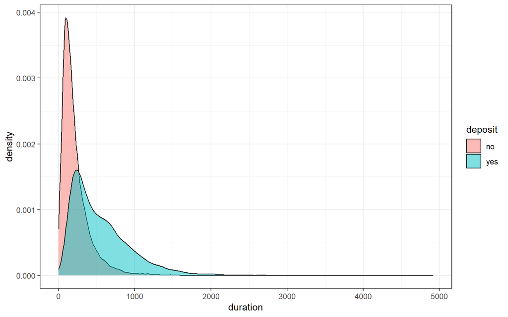

```r
ggplot(data, aes(duration, fill = deposit)) +
  geom_density(alpha = 0.5) +
  theme_bw()
```

# 4. Prepare Data

## 4.1. Missing values

Let’s count missing values:

```r
colSums(is.na(data)) %>%
  sort()
```

```
       age            job        marital      education        default
         0              0              0              0              0
   housing           loan        contact          month    day_of_week
         0              0              0              0              0
  duration       campaign          pdays       previous       poutcome
         0              0              0              0              0
```

emp.var.rate cons.price.idx cons.conf.idx euribor3m nr.employed 0 0 0 0 0 deposit 0

We do not have missing values.

## 4.2. Data Transforms

### Previous

Some of them have 8-11 levels. Let’s see these variables in more details

```r
table(data$previous)
```

```
    0     1     2     3     4     5     6     7
35563  4561   754   216    70    18     5     1
```

We could add previous 6 and 7 to 5. It will make more sense.

```r
data$previous[data$previous==7] <- 5
data$previous[data$previous==6] <- 5
```

### Job

```r
table(data$job)
```

```
       admin.   blue-collar  entrepreneur     housemaid    management
        10422          9254          1456          1060          2924
      retired self-employed      services       student    technician
         1720          1421          3969           875          6743
   unemployed       unknown
         1014           330
```

We will change names “unknown” in all variables to avoid issues during running models.

```r
#data$job[data$job=="unknown"] <- "job_unknown"
data$job <- plyr::revalue(data$job, c("unknown"="job.unknown"))
```

### Marital status

```r
table(data$marital)
```

```
divorced  married   single  unknown
    4612    24928    11568       80
```

We will add “unknown” group to “married” - the biggest group.

```r
data$marital <- plyr::revalue(data$marital, c("unknown"="married"))
```

### Education

```r
table(data$education)
```

```
           basic.4y            basic.6y            basic.9y         high.school
               4176                2292                6045                9515
         illiterate professional.course   university.degree             unknown
                 18                5243               12168                1731
```

We will rename “unknown” group to “edu.unknown”.

```r
data$education <- plyr::revalue(data$education, c("unknown"="edu.unknown"))
```

### Default

```r
table(data$default)
```

```
     no unknown     yes
  32588    8597       3
```

We will change “unknown” to “def.unknown” and add 3 “yes” to that group. It will make more sense.

```r
data$default <- plyr::revalue(data$default, c("unknown"="def.unknown"))
data$default <- plyr::revalue(data$default, c("yes"="def.unknown"))
```

### Housing

```r
table(data$housing)
```

```
     no unknown     yes
  18622     990   21576
```

We will change “unknown” to “ho.unknown”.

```r
data$housing <- plyr::revalue(data$housing, c("unknown"="ho.unknown"))
```

### Loan

```r
table(data$loan)
```

```
     no unknown     yes
  33950     990    6248
```

We will change “unknown” to “no” - biggest group.

```r
data$loan <- plyr::revalue(data$loan, c("unknown"="no"))
```

### pdays

```r
table(data$pdays)
```

```
    0     1     2     3     4     5     6     7     8     9    10    11    12
   15    26    61   439   118    46   412    60    18    64    52    28    58
   13    14    15    16    17    18    19    20    21    22    25    26    27
   36    20    24    11     8     7     3     1     2     3     1     1     1
  999
39673
```

We can see that there is big deviation. Those there were not contacted have 999. We will assign 0 instead.

```r
data$pdays[data$pdays==999] <- 0
```

## 4.3. Data partitioning

```r
set.seed(987654321)

data_which_train <- createDataPartition(data$deposit, # target variable
                                          # share of the training sample
                                          p = 0.7,
                                          list = FALSE)

# It is a vector of numbers - indexes of 70% of observations selected
head(data_which_train)
```

```
 Resample1
```

[1,] 1 [2,] 3 [3,] 7 [4,] 8 [5,] 9 [6,] 10

```r
# We need to apply this index for data division
data_train <- data[data_which_train,]
data_test <- data[-data_which_train,]
```

## 4.4. Feature Selection

**Correlation**

Let’s observer the correlation between numerical variables

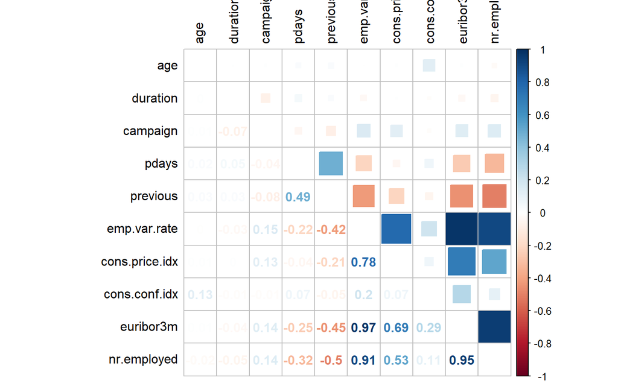

```r
data_correlations <-
  cor(data_train[,data_numeric_vars],
      use = "pairwise.complete.obs")

corrplot.mixed(data_correlations,
               upper = "square",
               lower = "number",
               tl.col="black", # color of labels (variable names)
               tl.pos = "lt")  # position of labels (lt = left and top)
```

There are correlation between euribor3nm and emp.var.rate, between nr.employed and emp.var.rate, euribor3nm and cons.price.idx, fair correlation between cons.price.idx and nr.employed, between cons.conf.inx and euribor3m

**Note:** As our dependent variable is categorical, we cannot observe in corrplot.mixed function.

Correlation between target variable (categorical/binomial) and other categorical variables. We will use `Cramer's V` coefficient from Chi2 test statistic. `Cramer's V` takes values from 0 to 1, where higher values mean a stronger relationship (if both variables have only two levels `Cramer's V` take values from -1 to 1)

All categorical variables:

```r
data_categorical_vars
```

```
 [1] "job"         "marital"     "education"   "default"     "housing"
 [6] "loan"        "contact"     "month"       "day_of_week" "poutcome"
[11] "deposit"
```

**Deposit vs Education**

```r
education <- DescTools::CramerV(data_train$deposit,
                   data_train$education)

education
```

```
[1] 0.0688281
```

We will repeat the same for all other categorical variables.

```r
kable(data.frame(education, job, marital, default, housing, loan, contact, month, day_of_week, poutcome), capture = "Correlation between target & categorical variables")
```

| education | job | marital | default | housing | loan | contact | month | day_of_week | poutcome |
| --- | --- | --- | --- | --- | --- | --- | --- | --- | --- |
| 0.0688281 | 0.1469663 | 0.0498343 | 0.0959846 | 0.0080898 | 0.008121 | 0.1437512 | 0.270277 | 0.0269256 | 0.3227672 |

Moderately strong relationship `Deposit` vs `poutcome` and `Deposit` vs `Month`. However, correlation between target and other categorical variables are not strong.

**Feature engineering**

near zero

```r
nearZeroVar(data_train,
            saveMetrics = TRUE)
```

```
               freqRatio percentUnique zeroVar   nzv
age             1.049811   0.270532741   FALSE FALSE
job             1.128347   0.041620422   FALSE FALSE
marital         2.145508   0.010405105   FALSE FALSE
education       1.276161   0.027746948   FALSE FALSE
default         3.838396   0.006936737   FALSE FALSE
housing         1.155496   0.010405105   FALSE FALSE
loan            5.649446   0.006936737   FALSE FALSE
contact         1.757196   0.006936737   FALSE FALSE
month           1.935246   0.034683685   FALSE FALSE
day_of_week     1.020360   0.017341842   FALSE FALSE
duration        1.042017   5.004855716   FALSE FALSE
campaign        1.671903   0.135266371   FALSE FALSE
pdays          92.633333   0.083240844   FALSE  TRUE
previous        7.721912   0.020810211   FALSE FALSE
poutcome        8.287808   0.010405105   FALSE FALSE
emp.var.rate    1.735096   0.034683685   FALSE FALSE
cons.price.idx  1.149286   0.090177580   FALSE FALSE
cons.conf.idx   1.149286   0.090177580   FALSE FALSE
 [ reached 'max' / getOption("max.print") -- omitted 3 rows ]
```

Let’s see the problematic value index

```r
nearZeroVar(data_train)
```

```
[1] 13
```

Identification of linear relationships in the data

Let’s find out redundant variables as redundant, those that can be determined from the others. They do not bring anything to the analysis

Llets check it for numeric variables

```r
( findLinearCombos(data_train[, data_numeric_vars] ) ->
    houses_linearCombos )
```

```
$linearCombos
list()

$remove
NULL
```

No linear combination found.

# 5. Evaluate Algorithms

## 5.1. Test options and evaluation metric

We will set 5-fold `cross validation` to estimate `accuracy`.

by using cross validation on the training sample we can determine the EXPECTED forecast error WITHOUT looking into the test data

```r
control <- trainControl(method="cv", number=5)
metric <- "Accuracy" # also "ROC"
```

We are using the metric of `accuracy` to evaluate models. This is a ratio of the number of correctly predicted instances in divided by the total number of instances in the dataset multiplied by 100 to give a percentage (e.g. 95% accurate). We will be using the metric variable when we run build and evaluate each model next.

## 5.2. Compare Algorithms – Accuracy

We will use a couple of algorithms. From linear algorithms we will use glm, lda and qda. From nonlinear algorithms we will use CART and KNN.

```r
# logistic regression
set.seed(987654321)
fit.glm <- train(deposit ~ ., data = data_train, method = "glm", family = "binomial",
    metric = metric, trControl = control)
# a) linear algorithms LDA
set.seed(987654321)
fit.lda1 <- train(deposit ~ ., data = data_train, method = "lda", metric = metric,
    trControl = control)
# LDA2
set.seed(987654321)
fit.lda2 <- train(deposit ~ ., data = data_train, method = "lda", metric = metric,
    trControl = control, prior = c(0.5, 0.5))
# QDA
set.seed(987654321)
fit.qda1 <- train(deposit ~ ., data = data_train, method = "qda", metric = metric,
    trControl = control)
# QDA2
set.seed(987654321)
fit.qda2 <- train(deposit ~ ., data = data_train, method = "qda", metric = metric,
    trControl = control, prior = c(0.5, 0.5))
# b) nonlinear algorithms CART
set.seed(987654321)
fit.cart <- train(deposit ~ ., data = data_train, method = "rpart", metric = metric,
    trControl = control)
# kNN
set.seed(987654321)
fit.knn <- train(deposit ~ ., data = data_train, method = "knn", metric = metric,
    trControl = control)
```

Let’s see the results of the training by the algorithms. Summarize accuracy of models

```r
results <- resamples(list(glm = fit.glm, lda1 = fit.lda1, lda2 = fit.lda2, qda1 = fit.qda1,
    qda2 = fit.qda2, cart = fit.cart, knn = fit.knn))
summary(results)
```

```
Call:
summary.resamples(object = results)

Models: glm, lda1, lda2, qda1, qda2, cart, knn
Number of resamples: 5

Accuracy
          Min.   1st Qu.    Median      Mean   3rd Qu.      Max. NA's
glm  0.9046133 0.9094850 0.9120860 0.9101345 0.9122442 0.9122442    0
lda1 0.9040930 0.9061904 0.9099896 0.9083310 0.9103520 0.9110302    0
lda2 0.8751517 0.8805064 0.8820673 0.8809310 0.8822407 0.8846887    0
qda1 0.8614531 0.8659383 0.8664586 0.8660864 0.8680423 0.8685397    0
qda2 0.8598925 0.8622962 0.8628165 0.8637278 0.8662851 0.8673487    0
cart 0.9066944 0.9080978 0.9086022 0.9089554 0.9091382 0.9122442    0
knn  0.9025490 0.9033992 0.9046133 0.9048280 0.9065372 0.9070413    0

Kappa
          Min.   1st Qu.    Median      Mean   3rd Qu.      Max. NA's
glm  0.4360750 0.4639415 0.4736183 0.4645700 0.4739052 0.4753101    0
lda1 0.4766398 0.4887561 0.5071066 0.4980040 0.5073523 0.5101653    0
lda2 0.5226205 0.5293496 0.5343124 0.5344454 0.5411167 0.5448276    0
qda1 0.3996342 0.4044301 0.4128988 0.4107009 0.4137289 0.4228124    0
qda2 0.4070217 0.4084212 0.4117571 0.4144722 0.4159925 0.4291685    0
cart 0.5121568 0.5255892 0.5297832 0.5281110 0.5318901 0.5411358    0
knn  0.4646003 0.4713155 0.4728542 0.4742437 0.4799883 0.4824600    0
```

According to the results mean of `accuracy` is between 0.86 and 0.91. `accuracy` is quite high. The highest `accuracy` is in glm algorithm. The second place is cart. Let’s plot the the results to observe more details.

**Compare accuracy of models:**

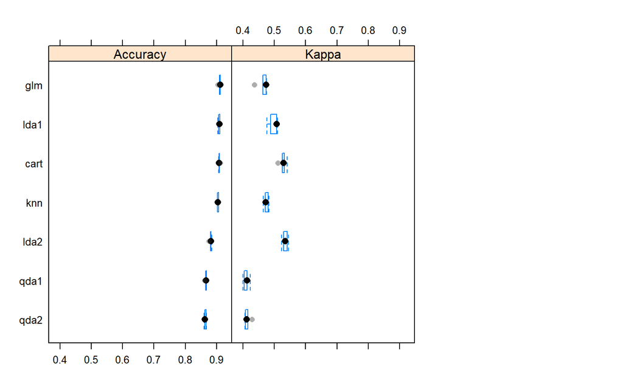

```r
theme1 <- trellis.par.get()
theme1$plot.symbol$col = rgb(0.2, 0.2, 0.2, 0.4)
theme1$plot.symbol$pch = 16
theme1$plot.line$col = rgb(1, 0, 0, 0.7)
theme1$plot.line$lwd <- 2
trellis.par.set(theme1)
bwplot(results, layout = c(3, 1))
```

Here on the above graph we can see that glm & cart has the best `accuracy` but with regards to `Kappa` the leader is cart and lda2. Let’s observe another measure “ROC” to see which is the best.

We will set 5-fold `cross validation` to estimate `ROC`.

```r
control1 <- trainControl(method = "cv", classProbs = TRUE, summaryFunction = twoClassSummary,
    number = 5)
metricROC <- "ROC"  # also 'ROC'
```

## 5.3 Compare Algorithms – ROC

```r
# logistic regression
set.seed(987654321)
fit.glmROC <- train(deposit ~ ., data = data_train, method = "glm", family = "binomial",
    metric = metricROC, trControl = control1)
# a) linear algorithms LDA
set.seed(987654321)
fit.lda1ROC <- train(deposit ~ ., data = data_train, method = "lda", metric = metricROC,
    trControl = control1)
# LDA2
set.seed(987654321)
fit.lda2ROC <- train(deposit ~ ., data = data_train, method = "lda", metric = metricROC,
    trControl = control1, prior = c(0.5, 0.5))
# QDA
set.seed(987654321)
fit.qda1ROC <- train(deposit ~ ., data = data_train, method = "qda", metric = metricROC,
    trControl = control1)
# QDA2
set.seed(987654321)
fit.qda2ROC <- train(deposit ~ ., data = data_train, method = "qda", metric = metricROC,
    trControl = control1, prior = c(0.5, 0.5))
# b) nonlinear algorithms CART
set.seed(987654321)
fit.cartROC <- train(deposit ~ ., data = data_train, method = "rpart", metric = metricROC,
    trControl = control1)
# kNN
set.seed(987654321)
fit.knnROC <- train(deposit ~ ., data = data_train, method = "knn", metric = metricROC,
    trControl = control1)
```

**Summary of training:**

```r
# summarize accuracy of models
resultsROC <- resamples(list(glmROC = fit.glmROC, lda1ROC = fit.lda1ROC, lda2ROC = fit.lda2ROC,
    qda1ROC = fit.qda1ROC, qda2ROC = fit.qda2ROC, cartROC = fit.cartROC, knnROC = fit.knnROC))

summary(resultsROC)
```

```
Call:
summary.resamples(object = resultsROC)

Models: glmROC, lda1ROC, lda2ROC, qda1ROC, qda2ROC, cartROC, knnROC
Number of resamples: 5

ROC
             Min.   1st Qu.    Median      Mean   3rd Qu.      Max. NA's
glmROC  0.9318329 0.9329036 0.9345076 0.9337335 0.9345660 0.9348576    0
lda1ROC 0.9288973 0.9326294 0.9326515 0.9328702 0.9344493 0.9357235    0
lda2ROC 0.9288973 0.9326294 0.9326515 0.9328702 0.9344493 0.9357235    0
qda1ROC 0.8708342 0.8709620 0.8738395 0.8748596 0.8760645 0.8825976    0
qda2ROC 0.8708327 0.8709601 0.8738395 0.8748608 0.8760741 0.8825976    0
cartROC 0.8378313 0.8388141 0.8445654 0.8440002 0.8492631 0.8495274    0
knnROC  0.8959181 0.8959207 0.8973037 0.8984188 0.8992022 0.9037495    0

Sens
             Min.   1st Qu.    Median      Mean   3rd Qu.      Max. NA's
glmROC  0.9687256 0.9716631 0.9742036 0.9727172 0.9743991 0.9745945    0
lda1ROC 0.9581704 0.9591558 0.9616963 0.9609520 0.9626734 0.9630643    0
lda2ROC 0.8848935 0.8915168 0.8923197 0.8923155 0.8962283 0.8966191    0
qda1ROC 0.8995505 0.9034591 0.9046316 0.9046672 0.9048270 0.9108679    0
qda2ROC 0.8946648 0.8962283 0.8993551 0.8993514 0.9017002 0.9048084    0
cartROC 0.9480164 0.9484073 0.9530975 0.9536820 0.9538702 0.9650186    0
knnROC  0.9577795 0.9581786 0.9603283 0.9601312 0.9620872 0.9622826    0

Spec
             Min.   1st Qu.    Median      Mean   3rd Qu.      Max. NA's
glmROC  0.4000000 0.4200000 0.4206471 0.4171829 0.4215385 0.4237288    0
lda1ROC 0.4784615 0.4892308 0.4984615 0.4938471 0.5007704 0.5023112    0
lda2ROC 0.7673344 0.7938462 0.7938462 0.7912523 0.7984615 0.8027735    0
qda1ROC 0.5353846 0.5615385 0.5654854 0.5621956 0.5701079 0.5784615    0
qda2ROC 0.5630769 0.5747304 0.5861538 0.5831291 0.5947612 0.5969231    0
cartROC 0.4961479 0.5523077 0.5630769 0.5566381 0.5778120 0.5938462    0
knnROC  0.4646154 0.4653313 0.4692308 0.4692113 0.4714946 0.4753846    0
```

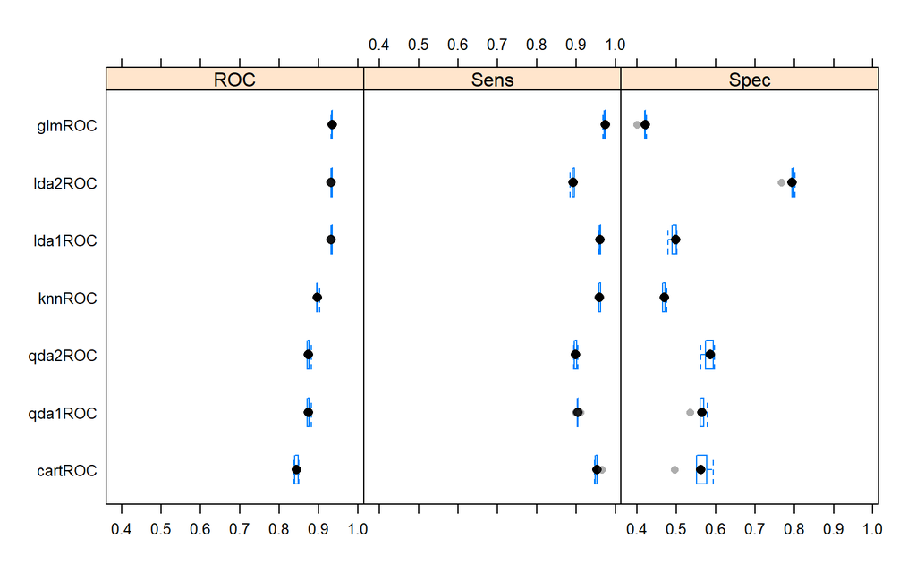

```r
theme1 <- trellis.par.get()
theme1$plot.symbol$col = rgb(0.2, 0.2, 0.2, 0.4)
theme1$plot.symbol$pch = 16
theme1$plot.line$col = rgb(1, 0, 0, 0.7)
theme1$plot.line$lwd <- 2
trellis.par.set(theme1)
bwplot(resultsROC, layout = c(3, 1))
```

**Summarize Best Model - Generalized Linear Model**

```r
# summarize Best Model
print(fit.glmROC)
```

```
Generalized Linear Model

28832 samples
   20 predictor
    2 classes: 'no', 'yes'

No pre-processing
Resampling: Cross-Validated (5 fold)
Summary of sample sizes: 23065, 23066, 23065, 23066, 23066
Resampling results:

  ROC        Sens       Spec
  0.9337335  0.9727172  0.4171829
```

```r
print(fit.glm)
```

```
Generalized Linear Model

28832 samples
   20 predictor
    2 classes: 'no', 'yes'

No pre-processing
Resampling: Cross-Validated (5 fold)
Summary of sample sizes: 23065, 23066, 23065, 23066, 23066
Resampling results:

  Accuracy   Kappa
  0.9101345  0.46457
```

**Summarize Model #2 Linear Discriminant Analysis**

```r
print(fit.lda1ROC)
```

```
Linear Discriminant Analysis

28832 samples
   20 predictor
    2 classes: 'no', 'yes'

No pre-processing
Resampling: Cross-Validated (5 fold)
Summary of sample sizes: 23065, 23066, 23065, 23066, 23066
Resampling results:

  ROC        Sens      Spec
  0.9328702  0.960952  0.4938471
```

```r
print(fit.lda1)
```

```
Linear Discriminant Analysis

28832 samples
   20 predictor
    2 classes: 'no', 'yes'

No pre-processing
Resampling: Cross-Validated (5 fold)
Summary of sample sizes: 23065, 23066, 23065, 23066, 23066
Resampling results:

  Accuracy  Kappa
  0.908331  0.498004
```

**Summarize Model #3 - CART**

```r
print(fit.cartROC)
```

```
CART

28832 samples
   20 predictor
    2 classes: 'no', 'yes'

No pre-processing
Resampling: Cross-Validated (5 fold)
Summary of sample sizes: 23065, 23066, 23065, 23066, 23066
Resampling results across tuning parameters:

  cp          ROC        Sens       Spec
  0.01662562  0.8440002  0.9536820  0.5566381
  0.02647783  0.7871642  0.9559095  0.5080484
  0.06727217  0.6622293  0.9720916  0.3192035

ROC was used to select the optimal model using the largest value.
The final value used for the model was cp = 0.01662562.
```

```r
print(fit.cart)
```

```
CART

28832 samples
   20 predictor
    2 classes: 'no', 'yes'

No pre-processing
Resampling: Cross-Validated (5 fold)
Summary of sample sizes: 23065, 23066, 23065, 23066, 23066
Resampling results across tuning parameters:

  cp          Accuracy   Kappa
  0.01662562  0.9089554  0.5281110
  0.02647783  0.9054525  0.4911998
  0.06727217  0.8985500  0.3396628

Accuracy was used to select the optimal model using the largest value.
The final value used for the model was cp = 0.01662562.
```

# 6. Finalize Model

## 6.1 Predictions on test dataset

**Predict with Generalized Linear Model**

```r
# lets see the forecast error on the test sample

data_test_forecasts <- predict(fit.glm, data_test, type = "prob")

# confusion matrix

confusionMatrix(data = as.factor(ifelse(data_test_forecasts["yes"] > 0.5, "yes",
    "no")), reference = data_test$deposit, positive = "yes")
```

```
Confusion Matrix and Statistics

          Reference
Prediction    no   yes
       no  10698   804
       yes   266   588

               Accuracy : 0.9134
                 95% CI : (0.9083, 0.9183)
    No Information Rate : 0.8873
    P-Value [Acc > NIR] : < 2.2e-16

                  Kappa : 0.479

 Mcnemar's Test P-Value : < 2.2e-16

            Sensitivity : 0.42241
            Specificity : 0.97574
         Pos Pred Value : 0.68852
         Neg Pred Value : 0.93010
             Prevalence : 0.11266
         Detection Rate : 0.04759
   Detection Prevalence : 0.06912
      Balanced Accuracy : 0.69908

       'Positive' Class : yes
```

**ROC/AUC**

```r
roc.area(ifelse(data_test$deposit == "yes", 1, 0), data_test_forecasts[, "yes"])$A
```

```
[1] 0.9374395
```

**Predict with Linear Discriminant Analysis**

```r
# lets see the forecast error on the test sample

data_test_forecasts_lda1 <- predict(fit.lda1, data_test, type = "prob")

# confusion matrix

confusionMatrix(data = as.factor(ifelse(data_test_forecasts_lda1["yes"] > 0.5, "yes",
    "no")), reference = data_test$deposit, positive = "yes")
```

```
Confusion Matrix and Statistics

          Reference
Prediction    no   yes
       no  10559   678
       yes   405   714

               Accuracy : 0.9124
                 95% CI : (0.9072, 0.9173)
    No Information Rate : 0.8873
    P-Value [Acc > NIR] : < 2.2e-16

                  Kappa : 0.5206

 Mcnemar's Test P-Value : < 2.2e-16

            Sensitivity : 0.51293
            Specificity : 0.96306
         Pos Pred Value : 0.63807
         Neg Pred Value : 0.93966
             Prevalence : 0.11266
         Detection Rate : 0.05779
   Detection Prevalence : 0.09056
      Balanced Accuracy : 0.73800

       'Positive' Class : yes
```

**ROC/AUC**

```r
roc.area(ifelse(data_test$deposit == "yes", 1, 0), data_test_forecasts_lda1[, "yes"])$A
```

```
[1] 0.9361191
```

**Predict with CART**

```r
# lets see the forecast error on the test sample

data_test_forecasts_cart <- predict(fit.cart, data_test, type = "prob")

# confusion matrix

confusionMatrix(data = as.factor(ifelse(data_test_forecasts_cart["yes"] > 0.5, "yes",
    "no")), reference = data_test$deposit, positive = "yes")
```

```
Confusion Matrix and Statistics

          Reference
Prediction    no   yes
       no  10408   576
       yes   556   816

               Accuracy : 0.9084
                 95% CI : (0.9032, 0.9134)
    No Information Rate : 0.8873
    P-Value [Acc > NIR] : 1.5e-14

                  Kappa : 0.5389

 Mcnemar's Test P-Value : 0.5723

            Sensitivity : 0.58621
            Specificity : 0.94929
         Pos Pred Value : 0.59475
         Neg Pred Value : 0.94756
             Prevalence : 0.11266
         Detection Rate : 0.06604
   Detection Prevalence : 0.11104
      Balanced Accuracy : 0.76775

       'Positive' Class : yes
```

**ROC/AUC**

```r
roc.area(ifelse(data_test$deposit == "yes", 1, 0), data_test_forecasts_cart[, "yes"])$A
```

```
[1] 0.8464413
```

**Predict with K-nearest neighbours**

```r
# lets see the forecast error on the test sample

data_test_forecasts_knn <- predict(fit.knn, data_test, type = "prob")

# confusion matrix

confusionMatrix(data = as.factor(ifelse(data_test_forecasts_knn["yes"] > 0.5, "yes",
    "no")), reference = data_test$deposit, positive = "yes")
```

```
Confusion Matrix and Statistics

          Reference
Prediction    no   yes
       no  10498   714
       yes   466   678

               Accuracy : 0.9045
                 95% CI : (0.8992, 0.9096)
    No Information Rate : 0.8873
    P-Value [Acc > NIR] : 3.712e-10

                  Kappa : 0.4821

 Mcnemar's Test P-Value : 6.458e-13

            Sensitivity : 0.48707
            Specificity : 0.95750
         Pos Pred Value : 0.59266
         Neg Pred Value : 0.93632
             Prevalence : 0.11266
         Detection Rate : 0.05487
   Detection Prevalence : 0.09259
      Balanced Accuracy : 0.72228

       'Positive' Class : yes
```

**ROC/AUC**

```r
roc.area(ifelse(data_test$deposit == "yes", 1, 0), data_test_forecasts_knn[, "yes"])$A
```

```
[1] 0.8904408
```

# 7. Conclusions

Project in nutshell:

- To predict whether customer subscribed to deposit or not we used data bank marketing campaign data consisted 41188 rows and 21 columns.
- We split the dataset into train and test datasets(70/30). We build machine learning models with different configuration and trained to get the best model.
- We chose glm, lda, cart & knn models with the same order. We based on its predictive accuracy. The process of data preparation, of training of dataset and model selection is in following document.
- The best prediction is by glm - `Accuracy 0.9134` and `ROC 0.9374395`. this could be a bit intuitive as glm is good in modeling logistic regressions.
- However, we could try tree based algorithms as well as they perform well in such data.
- Time complexity of the algorithms is big. Therefore algorithms like Random Forest would take a lot of time to train the data. However, in sake of improving accuracy could be considered.

# 8. References

Class materials provided by Piotr Wójcik PhD at the course “Machine Learning 1”, University of Warsaw, 2020

Link to the source: https://archive.ics.uci.edu/ml/datasets/Bank+Marketing

Source Paper: [Moro et al., 2014] S. Moro, P. Cortez and P. Rita. A Data-Driven Approach to Predict the Success of Bank Telemarketing. Decision Support Systems, Elsevier, 62:22-31, June 2014

Internet sources: https://machinelearningmastery.com/feature-selection-with-the-caret-r-package/

Knitr: https://yihui.org/knitr/options/#code-evaluation

About tests: https://stats.idre.ucla.edu/r/whatstat/what-statistical-analysis-should-i-usestatistical-analyses-using-r/#chisq

Photo source: https://unsplash.com/photos/6Y6OnwBKk-o